# Oxford Happiness Questionnaire

coop711

2025-04-21

# 옥스포드 행복도 조사 집계

## 실험의 목적

옥스포드 행복 설문지 실험결과를 분석합니다.

옥스포드 행복 설문지(Oxford Happiness Questionnaire)는 긍정심리학(Psychology of Happiness) 분야에서 널리쓰이는 자기보고식 설문도구로 “행복감(subjective well-being) 을 정량적으로 측정하기 위한 목적으로 1989년 Michael Argyle 과 Peter Hill 이 개발하였습니다.

총 29개 문항으로 구성되어 있으며 각 문항은 Likert 척도 (1~6점)로 응답하게 되어 있고, 일부는 역문항이 포함되어 있어서 점수를 환산할 때 주의가 필요합니다.

채점 방식은 문항당 1 ~ 6점으로 주어지고 전체 평균 점수를 계산하여 점수가 높을 수록 행복감이 높은 것으로 해석합니다.

평균 점수 1점 이상 2점 미만이면 “행복하지 않다”, 2점 이상 3점 미만이면 “다소 행복하지 않다”, 3점 이상 4점 미만이면 “그저 그렇다”, 4점 이상 5점 미만이면 “꽤 행복하다”, 5점 이상이면 “매우 행복하다”로 분류합니다.

이 실험에는 두 가지 목적이 있습니다.

첫째는 있는 그대로 옥스포드 행복 설문지로 측정하는 여러분의 행복 수준은 어느 정도인지,

둘째는 영문판으로 응답할 때와 국문판으로 응답할 때 어떤 차이가 있는지, 특히 응답에 소요되는 시간을 측정해서 비교해 보았습니다.

### Red, Black을 잘못 표시한 사람들

|  | Red(옥스포드행복설문지) | Black(옥스포드행복설문지) |
| --- | --- | --- |
| **Red(랜덤화출석부)** | 287 | 0 |
| **Black(랜덤화출석부)** | 1 | 284 |
| **계** | 288 | 284 |

랜덤화출석부에 있는 Red, Black 과 실제 구글설문에 올린 Red, Black 이 다른 사람들의 수효는 1명입니다.

Red를 Black 이라고 한 사람이 0명, Black 을 Red 라고 한 사람이 1명입니다.

### 응답인원의 Red, Black

Red(국문) 로 응답한 인원은 288명, Black(영문) 에 응답한 인원은 284명입니다.

전체 응답인원 572 명을 랜덤하게 둘로 나눌 때 어느 한 쪽의 기대인원은 이를 반으로 나눠 준 286명이고, 표준오차는 이의 제곱근에 1/2을 곱해 준 12 명입니다.

따라서 Red, Black 각 그룹에 관찰된 인원은 기대인원으로부터 표준오차 범위 안에 들어갑니다.

## 행복 점수 비교

국문 설문지와 영문 설문지의 행복점수를 비교합니다.

먼저 기초통계입니다.

행복점수 단계별로 비교했을 때나 기초통계로 비교했을 때 국문 설문지로 작성한 그룹 (Red)의 행복점수가 다소 높게 나오지만, 그 차이가 통계적으로 유의한 수준은 아닙니다.

### `summary()`

- **국문**:

  | Min. | 1st Qu. | Median | Mean | 3rd Qu. | Max. |
  | --- | --- | --- | --- | --- | --- |
  | 2 | 3.474 | 3.897 | 3.987 | 4.457 | 5.655 |

- **영문**:

  | Min. | 1st Qu. | Median | Mean | 3rd Qu. | Max. |
  | --- | --- | --- | --- | --- | --- |
  | 1.483 | 3.483 | 3.862 | 3.915 | 4.319 | 5.724 |

Red(국문) 집단의 평균 행복점수는 3.99, Black(영문) 집단의 평균 행복점수는 3.92 으로 국문 설문지에 응답한 행복점수의 평균이 0.072점 더 높게 나옵니다.

중위수를 비교하더라도 Red(국문) 집단의 행복점수 중위수는 3.90, Black(영문) 집단의 행복점수 중위수는 3.86 으로 국문 설문지에 응답한 행복점수의 중위수가 0.034 점 더 높게 나옵니다.

### `t.test()` on means

Welch Two Sample t-test: `Scores` by `group`

| Test statistic | df | P value | Alternative hypothesis | mean in group 국문 | mean in group 영문 |
| --- | --- | --- | --- | --- | --- |
| 1.343 | 563.6 | 0.1797 | two.sided | 3.987 | 3.915 |

국문 설문지에 대한 행복점수의 평균과 영문 설문지에 대한 행복점수의 평균에서 관찰된 차이가 통계적으로 유의한지 t-test 로 알아 봅니다.

양 집단의 표준편차를 알 수 없기 때문에 Welch 의 근사식을 활용합니다.

이 때 t-통계량은 1.34, 자유도는 563.63, p-value 는 0.1797라고 나옵니다.

즉, 통계적으로 유의한 차이를 관찰하지 못하였습니다.

국문 행복도 조사와 영문 행복도 조사의 평균 행복점수 차이는 랜덤화의 효과로 충분히 나올 수 있는 수준이라는 것입니다.

결과 요약표에는 각 집단의 평균 행복점수도 나와 있습니다.

지난 학기의 자료들을 살펴보면 국문으로 물어 봤을 때하고 영문으로 물어 봤을 때의 행복 점수에서 통계적으로 유의한 차이가 있었다는 것을 알 수 있습니다.

지난 자료와 금번 자료에서는 왜 이러한 차이가 관찰되는 걸까요?

### `table()`

|  | 행복하지 않다 | 다소 행복하지 않다 | 그저 그렇다 | 꽤 행복하다 | 매우 행복하다 | 계 |
| --- | --- | --- | --- | --- | --- | --- |
| **국문** | 0 | 11 | 148 | 100 | 29 | 288 |
| **영문** | 2 | 6 | 155 | 108 | 13 | 284 |
| **계** | 2 | 17 | 303 | 208 | 42 | 572 |

이번에는 국문 행복도 조사 결과와 영문 행복도 조사 결과를 등급별로 나누어 교차표를 계산해 보았습니다.

총 572 명 응답한 가운데 250명이 꽤 행복하다 이상으로 행복하다고 응답하였고 그저 그렇다고 응답 한 사람들이 303 명이었습니다.

국문, 영문의 차이는 어떤가요?

### `Cochran-ArmitageTest()`

Cochran-Armitage test for trend: `.`

| Test statistic | dim | P value | Alternative hypothesis |
| --- | --- | --- | --- |
| 1.278 | 5 | 0.2012 | two.sided |

국문, 영문 행복도 조사 결과의 등급별 차이가 통계적으로 유의한지 파악하기 위하여 순서형 변수 분석에 적합한 코크란-아미티지 테스트를 수행하였습니다.

그 결과 코크란-아미키지 통계량은 1.28, `dim`은 5, p-value 는 0.2012이므로 통계적으로 유의한 차이를 보이고 있지 않습니다.

### 백분율(%)

| 행복하지 않다 | 다소 행복하지 않다 | 그저 그렇다 | 꽤 행복하다 | 매우 행복하다 | 계 |
| --- | --- | --- | --- | --- | --- |
| 0.3 | 3.0 | 53.0 | 36.4 | 7.3 | 100.0 |

행복점수의 등급별 백분율을 파악해 보면 꽤 행복하다 이상이 43.71%이고, 그저 그렇다가 52.97%, 다소 행복하지 않다 이하가 3.32% 입니다.

### `geom_boxplot()`

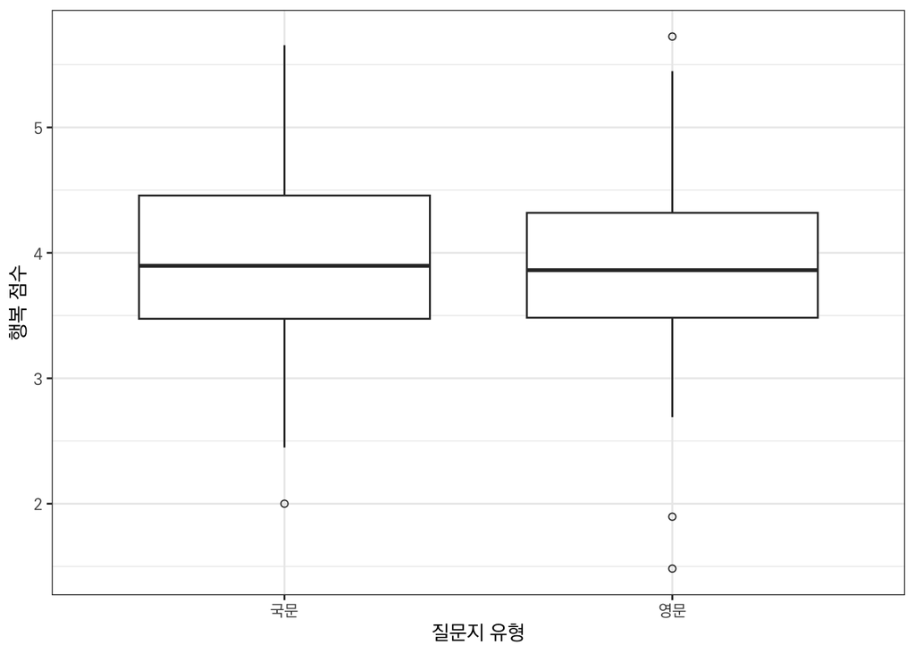

국문, 영문 행복도 조사 결과를 시각적으로 비교하기 위하여 Boxplot 을 그려 보았습니다.

그 밖에 기초 통계에 나오는 통계값들을 시각적으로 비교할 수 있습니다.

## 소요시간 비교

초 단위로 측정한 소요시간에서는 오전, 오후를 잘못 쓴다거나 시작 시간을 제출 시간보다 늦게 입력한 사람들도 있고, 과도하게 (한 시간 이상) 소요된 것으로 나오는 사람들이 있어서 일일이 찾아서 수정하였고, 한 시간 이상은 사실상 설문지를 작성하다가 다른 일을 하고 다시 돌아와 마치는 것으로 판단하여 NA 로 처리하였습니다.

기초 통계부터 살펴보겠습니다.

### `summary()`

- **국문**:

  | Min. | 1st Qu. | Median | Mean | 3rd Qu. | Max. |
  | --- | --- | --- | --- | --- | --- |
  | 17 | 130 | 190.5 | 292.6 | 296 | 3268 |

- **영문**:

  | Min. | 1st Qu. | Median | Mean | 3rd Qu. | Max. |
  | --- | --- | --- | --- | --- | --- |
  | 17 | 129.8 | 258 | 362.5 | 410.8 | 2981 |

국문 행복도 조사의 평균 소요시간은 292.58초, 영문 행복도 조사의 평균 소요시간은 362.47초이므로 평균적으로 69.9초, 즉 1분 10초 정도 국문 행복도 조사 시간이 덜 걸립니다.

소요시간의 중위수를 비교해 보아도 국문 행복도 조사 소요시간의 중위수는 190.50초, 영문 행복도 조사 소요시간의 중위수는 258.00초이므로 67.5 초, 약 1분 8초 만큼 국문 행복도 조사의 소요시간이 덜 걸립니다.

### `geom_boxplot()`

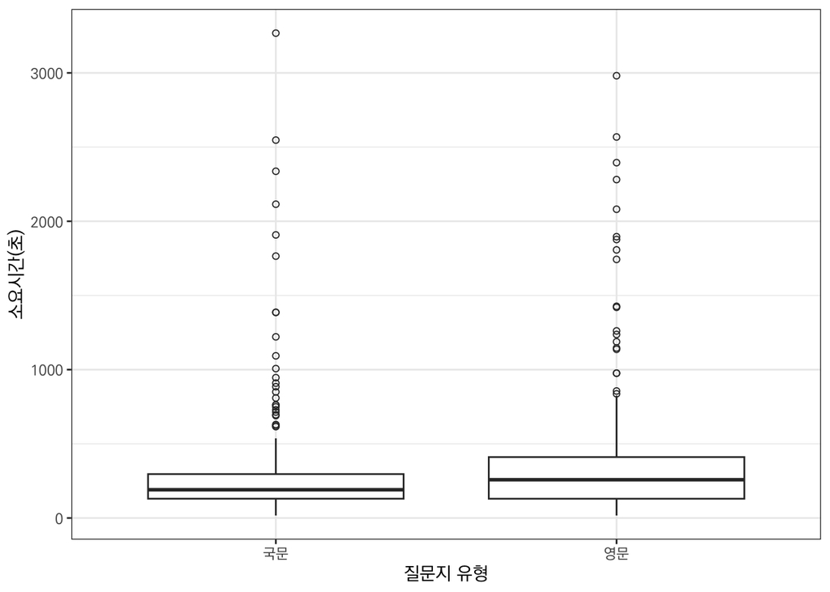

국문, 영문 행복도 조사 소요시간의 Boxplot 을 그려 보았습니다.

워낙 큰 값들이 많이 나오기 때문에 중위수 비교 등이 좀 어려운 측면이 있습니다.

### `t.test()` on means

Welch Two Sample t-test: `as.numeric(Duration)` by `group`

| Test statistic | df | P value | Alternative hypothesis | mean in group 국문 | mean in group 영문 |
| --- | --- | --- | --- | --- | --- |
| -2.12 | 560.4 | 0.03447 * | two.sided | 292.6 | 362.5 |

국문, 영문 행복도 조사의 소요 시간에 대해서도 t-test 를 수행하였는데 t-통계량은 -2.12, 자유도는 560.42, p-value 는 0.034이어서 통계적으로 유의한 차이가 관찰되고 있습니다.

## 마감 시간으로부터 제출 시간의 분포

### 분포표

일 단위

|  | [0,1] | (1,2] | (2,3] | (3,4] | (4,5] | (5,6] | (6,7] | (7,8] | (8,9] | (9,10] | (10,11] | (11,12] | (12,13] | (13,14] | 계 |
| --- | --- | --- | --- | --- | --- | --- | --- | --- | --- | --- | --- | --- | --- | --- | --- |
| **국문** | 120 | 16 | 12 | 8 | 4 | 5 | 6 | 39 | 19 | 9 | 14 | 15 | 7 | 14 | 288 |
| **영문** | 117 | 20 | 15 | 6 | 2 | 6 | 7 | 36 | 20 | 8 | 7 | 12 | 8 | 20 | 284 |
| **계** | 237 | 36 | 27 | 14 | 6 | 11 | 13 | 75 | 39 | 17 | 21 | 27 | 15 | 34 | 572 |

분포표로부터 두 가지 문제를 살펴보겠습니다.

첫째, 날마다 고르게 제출하는가?

둘째, Red(국문), Black(영문) 간에 통계적으로 유의한 차이가 있는가?

각 문제를 살펴보기 위해서는 분포표의 일부분을 대상으로 카이제곱 테스트를 수행합니다.

### 날마다 고르게 제출하는가?

| [0,1] | (1,2] | (2,3] | (3,4] | (4,5] | (5,6] | (6,7] | (7,8] | (8,9] | (9,10] | (10,11] | (11,12] | (12,13] | (13,14] |
| --- | --- | --- | --- | --- | --- | --- | --- | --- | --- | --- | --- | --- | --- |
| 237 | 36 | 27 | 14 | 6 | 11 | 13 | 75 | 39 | 17 | 21 | 27 | 15 | 34 |

Chi-squared test for given probabilities: `.`

| Test statistic | df | P value |
| --- | --- | --- |
| 1110 | 13 | 5.117e-229 * * * |

날마다 고르게 제출하는지 알아 보았습니다.

분포표의 “계”행에서 ’계’열을 제외하고 카이제곱테스트를 수행합니다.

분포표 만으로도 쉽게 파악할 수 있지만 카이제곱테스트가 명확히 해 줍니다.

카이제곱 통계량은 1109.52, 자유도는 13.00, p-value 는 5.1e-229 이므로 제출은 고르지 않고 특정 날짜에 치우쳐 있습니다.

막대그래프로 살펴 보겠습니다.

### 막대그래프

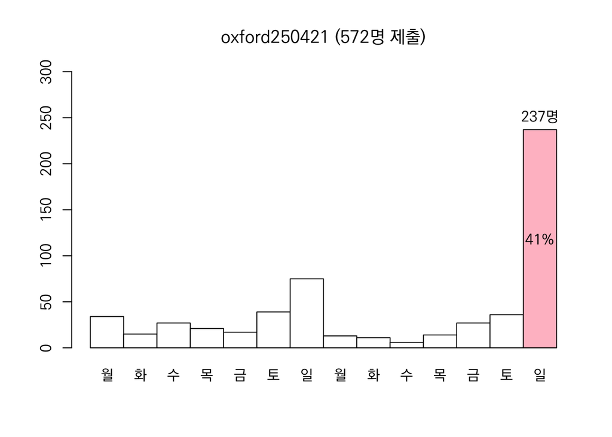

### Red(국문), Black(영문) 간에 닮았는가?

|  | [0,1] | (1,2] | (2,3] | (3,4] | (4,5] | (5,6] | (6,7] | (7,8] | (8,9] | (9,10] | (10,11] | (11,12] | (12,13] | (13,14] |
| --- | --- | --- | --- | --- | --- | --- | --- | --- | --- | --- | --- | --- | --- | --- |
| **국문** | 120 | 16 | 12 | 8 | 4 | 5 | 6 | 39 | 19 | 9 | 14 | 15 | 7 | 14 |
| **영문** | 117 | 20 | 15 | 6 | 2 | 6 | 7 | 36 | 20 | 8 | 7 | 12 | 8 | 20 |

Pearson’s Chi-squared test: `.`

| Test statistic | df | P value |
| --- | --- | --- |
| 5.905 | 13 | 0.9495 |

제출시간의 분포가 Red(국문), Black(영문) 간에 닮았는지 알아 보았습니다.

이번에는 분포표의 첫번쨰와 두번쨰 행, ’계’열을 제외한 나머지 열에 대해서 카이제곱테스트를 수행합니다.

카이제곱 통계량은 5.90, 자유도는 13, p-value 는 0.95 이므로 제출 시간의 분포는 Red(국문), Black(영문) 간에 통계적으로 유의한 차이가 관찰되지 않습니다.

이 사실을 Mosaic Plot 을 이용하여 시각적으로 살펴보겠습니다. 닮았다고 느껴지나요?

### Mosaic Plot

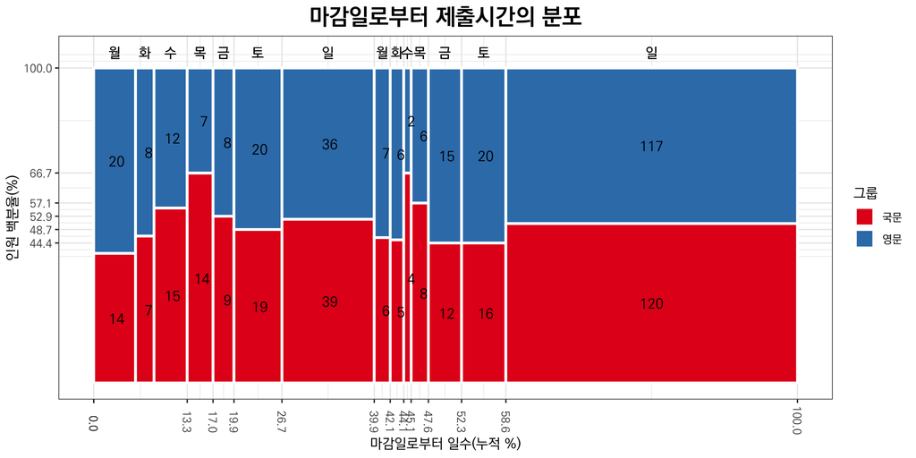